# Nested F Statistics - The Case of the Idaho Giant Salamander

March 14 2016

### Background

In our previous unit, we saw how we could quantify population subdivision based on variation in allele frequencies among subpopulations. However, we only considered the simplest possible case, one in which there are some number populations, and we want to assess how well they are differentiated from one another. But consider another possibility - suppose we’d like to look at multiple levels of division - for example among populations within a region, among regions within a continent, etc. A wonderful paper on Idaho Giant Salamanders MULLEN *et al.* (2010) does just that (albeit on a smaller scale). This is the creature:

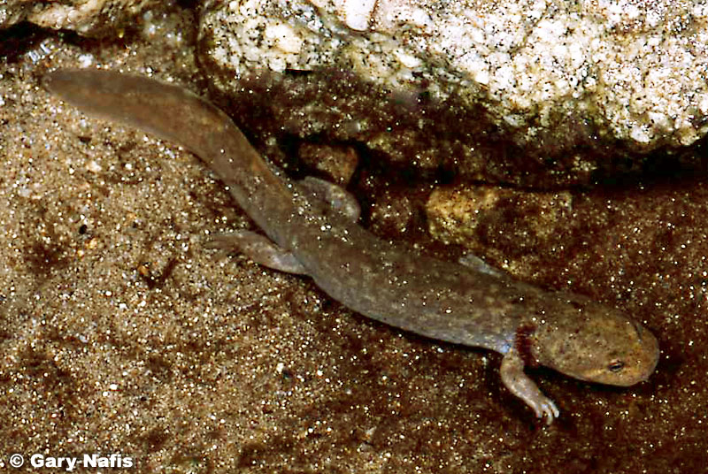

And the habitat they examined in Northern Idaho was ideal for nested Fst analysis. They looked at three river basins - the Lochsa, the St. Joe, and the St. Regis. Each of those basins consist of multiple catchments, each one of which is fed by a number of streams. A schematic of a typical basin is shown below:

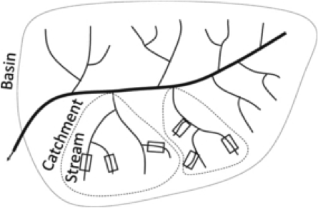

(Figure 2 from Mullen et al., 2010)

More detail can be seen in their Figure 3, which shows the overall region, as well as details of the three basins:

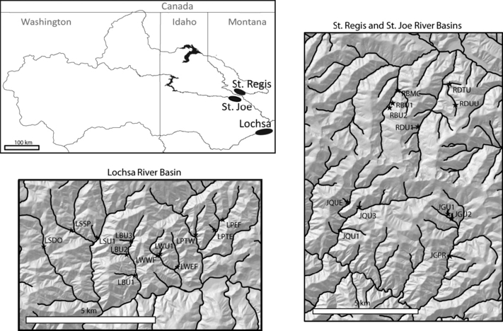

What Mullen et al set out to do was to ask which of the four models illustrated below best describes the population structure of these salamanders (their Figure 1).

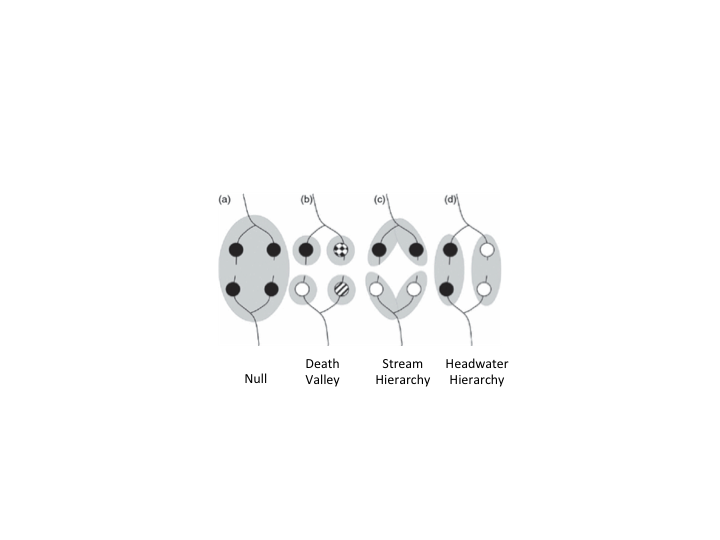

- The Null model is one in which there is no diversification - in essence the subpopulations form one panmictic population
- The Death Valley model supposes that the subpopulations are completely isolated and have been subject to independent genetic drift.
- The Stream Hierarchy model suggests that as aquatic animals, they are capable of moving through connected waterways but not over land.
- The Head Water Hierarchy model proposes that animals are restricted to the headwater regions of individual streams, and whatever gene flow occurs does so terrestrially.

So which of these best fits the data?